# Kruskal-Wallis Approach

```r
library(mosaic) # for the favstats
library(car)
library(DT)
library(pander)
library(readr)
food <- read_csv("food.csv") #food.csv is in the Data folder...
```

## Background

- A higher GPA score denotes a higher nutritional value frequency?
- Is the GPA score stochastically different based on the frequency check for nutritional values?
- Students that check the nutritional facts more often have stochastically better GPA scores?

These questions are aiming at one specific analysis which will be calculated using the Kruskal-Wallis test.

For the ‘nutritional check’ question, students had to choose the frequency of when they check the nutritional values, they had to choose from the following options:

- Never
- Almost never
- Sometimes
- Almost always
- Always

This options puts them into different categories. This analysis consist in finding a stochastically difference between the nutritional check category and their GPA scores.

The null and alternative hypotheses are written as:

$$H_0: \text{All nutritional checking frequency groups have the same GPA
score distribution.}$$
$$H_a: \text{At least one nutritional checking frequency group is
stochastically different.}$$
Significance level for this study will be set at:
$$\alpha = 0.05$$

## Analysis

```r
# new dataset with columns I will be using
food_analysis_selection <- food %>%
  select(c('GPA', 'nutritional_check'))

# fix the missing data and/or misspelling

# value 'Personal'   on row 62  was changed to 'NA'   and it was ignored in the analysis.
# value 'Unknown'    on row 105 was changed to 'NA'   and it was ignored in the analysis.
# value '3.79 bitch' on row 74  was changed to '3.79' and it was part of    the analysis.

food_analysis_selection$GPA[62 ] = NA
food_analysis_selection$GPA[105] = NA
food_analysis_selection$GPA[74 ] = 3.79

# Label 'nutritional_check' groups

food_analysis_noFactor <- food_analysis_selection %>%
  mutate(
    nutritional_check = case_when(
      nutritional_check == '1' ~ "Never",
      nutritional_check == '2' ~ "Almost never",
      nutritional_check == '3' ~ "Sometimes",
      nutritional_check == '4' ~ "Almost always",
      nutritional_check == '5' ~ "Always"
    )
  )

# Convert nutritional_check column to qualitative values
# Convert GPA               column to numerical   values
food_analysis_factor_and_numeric <-  food_analysis_noFactor %>%
  mutate(
    nutritional_check = factor(nutritional_check, levels = c("Never", "Almost never", "Sometimes", "Almost always", "Always")),
    GPA = as.numeric(GPA)
  )

food_analysis <-  food_analysis_factor_and_numeric %>%
  select(c('GPA', 'nutritional_check')) %>%
  na.omit()
```

**Data Summary Table**

The highest median is found in the ‘Sometimes’ and ‘Almost always’ groups. We would benefit from a Blox Plot to more easy see how these groups compare with each other.

```r
# Kruskal-Test Analysis

pander(favstats(GPA ~ nutritional_check, data = food_analysis)[,-10])
```

| nutritional_check | min | Q1 | median | Q3 | max | mean | sd | n |
| --- | --- | --- | --- | --- | --- | --- | --- | --- |
| Never | 2.2 | 3 | 3.2 | 3.292 | 3.6 | 3.016 | 0.4777 | 9 |
| Almost never | 2.71 | 3.2 | 3.5 | 3.685 | 3.92 | 3.435 | 0.3007 | 36 |
| Sometimes | 2.6 | 3.387 | 3.6 | 3.7 | 3.9 | 3.497 | 0.3553 | 20 |
| Almost always | 2.6 | 3 | 3.6 | 3.8 | 4 | 3.473 | 0.4061 | 41 |
| Always | 2.4 | 3.2 | 3.3 | 3.695 | 3.904 | 3.368 | 0.4239 | 15 |

**Box Plot Chat**

Students with a 4.0 GPA are found in the ‘Almost always’ group, which is also the group with the highest GPA median. Students that never check the nutritional food values are in the lowest GPA group. From this point, we would need to check the P-Value to confirm or reject assumptions, as well as rejecting or failing to reject the null hypothesis.

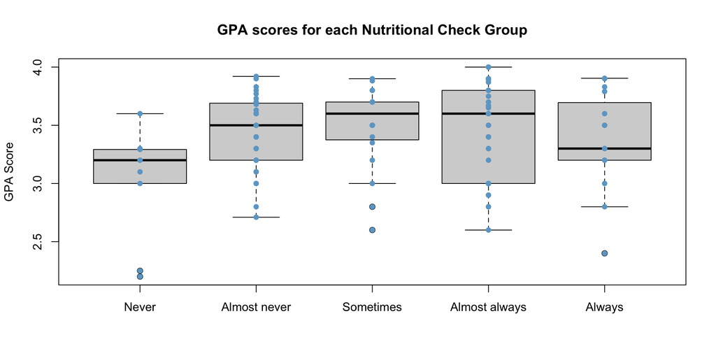

```r
# Kruskal-Test Analysis

boxplot(GPA ~ nutritional_check, data = food_analysis,
        col="lightgray", xlab="", main="GPA scores for each Nutritional Check Group", ylab="GPA Score")
stripchart(GPA ~ nutritional_check, data = food_analysis,
           vertical=TRUE, pch=16, add=TRUE, col="skyblue3")
```

**Kruskal-Wallis Test Results**

```r
# Kruskal-Test Analysis

pander(kruskal.test(GPA ~ nutritional_check, data = food_analysis))
```

Kruskal-Wallis rank sum test: `GPA` by `nutritional_check`

| Test statistic | df | P value |
| --- | --- | --- |
| 9.188 | 4 | 0.05657 |

### Interpretation

There is insufficient evidence to reject the null hypothesis that each of these represents a sample from the same distribution (p = 0.05657 > $\alpha$). This means that we will continue to assume that the GPA score distributions are the same across all frequency of the nutritional check values.